# Shape Digital - Senior Data Scientist Test

## Introduction & Pre-processing

First, we'll load the data and handle missing values.

```python
import pandas as pd
import numpy as np
import matplotlib.pyplot as plt
import seaborn as sns
from sklearn.model_selection import train_test_split
from sklearn.metrics import classification_report, f1_score, roc_auc_score, confusion_matrix
import xgboost as xgb
import shap
import warnings
import joblib

warnings.filterwarnings('ignore')
sns.set_theme(style='whitegrid')

# Load data
df = pd.read_csv('Test-O_G_Equipment_Data.csv')

# Preprocess Fail column
df['Fail'] = df['Fail'].fillna(0)
print(df.info())
display(df.head())
```

```
<class 'pandas.core.frame.DataFrame'>
RangeIndex: 800 entries, 0 to 799
Data columns (total 10 columns):
 #   Column       Non-Null Count  Dtype
---  ------       --------------  -----
 0   Cycle        800 non-null    int64
 1   Preset_1     800 non-null    int64
 2   Preset_2     800 non-null    int64
 3   Temperature  800 non-null    float64
 4   Pressure     800 non-null    float64
 5   VibrationX   800 non-null    float64
 6   VibrationY   800 non-null    float64
 7   VibrationZ   800 non-null    float64
 8   Frequency    800 non-null    float64
 9   Fail         800 non-null    float64
dtypes: float64(7), int64(3)
memory usage: 62.6 KB
None
```

|  | Cycle | Preset_1 | Preset_2 | Temperature | Pressure | VibrationX | VibrationY | VibrationZ | Frequency | Fail |
| --- | --- | --- | --- | --- | --- | --- | --- | --- | --- | --- |
| 0 | 1 | 3 | 6 | 44.2352 | 47.6573 | 46.4418 | 64.8203 | 66.4545 | 44.4832 | 0.0 |
| 1 | 2 | 2 | 4 | 60.8072 | 63.1721 | 62.0060 | 80.7144 | 81.2464 | 60.2287 | 0.0 |
| 2 | 3 | 2 | 1 | 79.0275 | 83.0322 | 82.6421 | 98.2544 | 98.7852 | 80.9935 | 0.0 |
| 3 | 4 | 2 | 3 | 79.7162 | 100.5086 | 122.3623 | 121.3634 | 118.6525 | 80.3156 | 0.0 |
| 4 | 5 | 2 | 5 | 39.9891 | 51.7648 | 42.5143 | 61.0379 | 50.7165 | 64.2452 | 0.0 |

### Task 1: Calculate how many times the equipment has failed.

A failure event is defined as a continuous block where `Fail == 1`.

```python
# Identify continuous blocks of failures
df['Failure_Event'] = (df['Fail'] != df['Fail'].shift(1)).cumsum()
failure_events = df[df['Fail'] == 1]['Failure_Event'].nunique()

print(f"The equipment has failed {failure_events} times.")
```

```
The equipment has failed 10 times.
```

### Task 2: Categorize equipment failures by setup configurations (Preset 1 and Preset 2)

We'll check how failures are distributed across different presets.

|  | Preset_1 | Preset_2 | Failure_Duration | Failure_Events |
| --- | --- | --- | --- | --- |
| 4 | 1 | 5 | 5 | 4 |
| 1 | 1 | 2 | 5 | 3 |
| 0 | 1 | 1 | 4 | 3 |
| 5 | 1 | 6 | 3 | 3 |
| 16 | 3 | 1 | 3 | 3 |
| 12 | 2 | 5 | 3 | 3 |
| 13 | 2 | 6 | 3 | 3 |
| 20 | 3 | 6 | 3 | 3 |
| 15 | 2 | 8 | 4 | 3 |
| 2 | 1 | 3 | 2 | 2 |
| 19 | 3 | 5 | 4 | 2 |
| 18 | 3 | 3 | 2 | 2 |
| 14 | 2 | 7 | 2 | 2 |
| 8 | 2 | 1 | 4 | 2 |
| 10 | 2 | 3 | 2 | 2 |
| 21 | 3 | 7 | 3 | 2 |
| 17 | 3 | 2 | 2 | 2 |
| 6 | 1 | 7 | 4 | 1 |
| 3 | 1 | 4 | 2 | 1 |
| 11 | 2 | 4 | 1 | 1 |
| 9 | 2 | 2 | 2 | 1 |
| 7 | 1 | 8 | 2 | 1 |
| 22 | 3 | 8 | 1 | 1 |

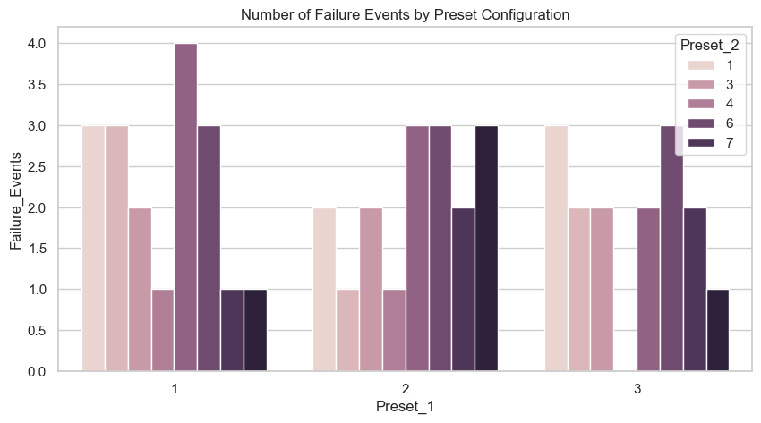

```
Insight: Specific configurations may be inherently more prone to cause failures or are operated much longer. Preset configurations seem to have a significant role.
```

```python
failures_only = df[df['Fail'] == 1]

preset_fail_counts = failures_only.groupby(['Preset_1', 'Preset_2']).size().reset_index(name='Failure_Duration')
preset_fail_events = failures_only.groupby(['Preset_1', 'Preset_2'])['Failure_Event'].nunique().reset_index(name='Failure_Events')

preset_summary = pd.merge(preset_fail_counts, preset_fail_events, on=['Preset_1', 'Preset_2'])
display(preset_summary.sort_values(by='Failure_Events', ascending=False))

plt.figure(figsize=(10, 5))
sns.barplot(data=preset_summary, x='Preset_1', y='Failure_Events', hue='Preset_2')
plt.title('Number of Failure Events by Preset Configuration')
plt.show()

print("Insight: Specific configurations may be inherently more prone to cause failures or are operated much longer. Preset configurations seem to have a significant role.")
```

### Task 3: Categorize equipment failures by their nature/root cause according to parameter readings

We compare the distributions of sensor readings during normal vs. failure states. We also analyze reading patterns just before a failure.

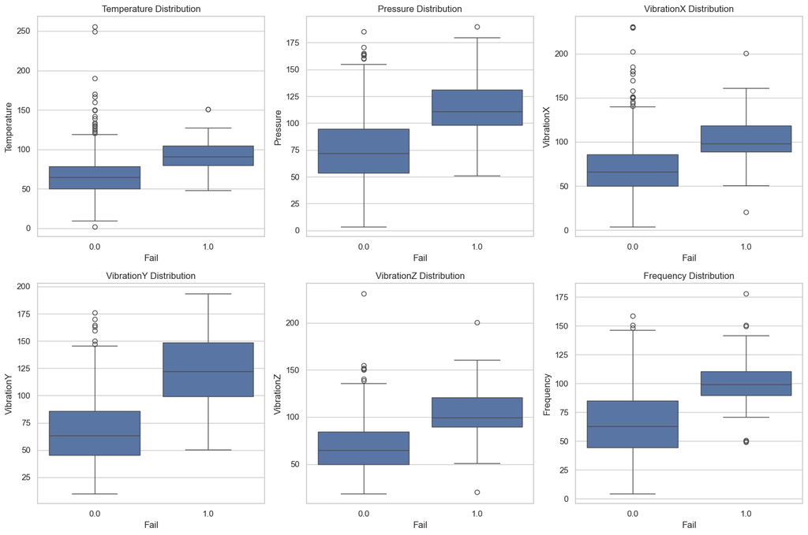

```
Insight: Abnormal distributions can indicate the root cause. E.g. high temperatures or extreme vibrations.
```

```python
# Distributions
features = ['Temperature', 'Pressure', 'VibrationX', 'VibrationY', 'VibrationZ', 'Frequency']
plt.figure(figsize=(15, 10))
for i, feature in enumerate(features, 1):
    plt.subplot(2, 3, i)
    sns.boxplot(x='Fail', y=feature, data=df)
    plt.title(f'{feature} Distribution')
plt.tight_layout()
plt.show()

print("Insight: Abnormal distributions can indicate the root cause. E.g. high temperatures or extreme vibrations.")
```

### Task 4: Predictive Modeling

```python
# Create target: Will fail in the next 5 cycles?
HORIZON = 5
df['Target'] = df['Fail'].shift(-HORIZON).rolling(HORIZON).max().fillna(0)
# We don't want to predict during a failure state, so let's only predict during normal operation
predict_df = df[df['Fail'] == 0].copy()

drop_cols = ['Cycle', 'Fail', 'Failure_Event', 'Target']
X = predict_df.drop(columns=drop_cols)
y = predict_df['Target']

# Time-based train-test split (e.g. first 80% train, last 20% test)
split_idx = int(len(predict_df) * 0.8)

X_train, X_test = X.iloc[:split_idx], X.iloc[split_idx:]
y_train, y_test = y.iloc[:split_idx], y.iloc[split_idx:]

print(f"Train size: {X_train.shape}, Test size: {X_test.shape}")
print(f"Train failures: {y_train.sum()}, Test failures: {y_test.sum()}")

model = xgb.XGBClassifier(eval_metric='logloss', random_state=42, scale_pos_weight=10)
model.fit(X_train, y_train)

y_pred = model.predict(X_test)
print(classification_report(y_test, y_pred))
print(f"ROC-AUC: {roc_auc_score(y_test, model.predict_proba(X_test)[:,1]):.4f}")

# Save the model for API consumption
joblib.dump(model, 'xgboost_model.pkl')
print("Model saved to xgboost_model.pkl")
```

```
Train size: (587, 8), Test size: (147, 8)
Train failures: 35.0, Test failures: 10.0
              precision    recall  f1-score   support

         0.0       0.93      0.99      0.96       137
         1.0       0.00      0.00      0.00        10

    accuracy                           0.93       147
   macro avg       0.47      0.50      0.48       147
weighted avg       0.87      0.93      0.90       147

ROC-AUC: 0.6044
Model saved to xgboost_model.pkl
```

### Task 5: Variable Importance

We analyze which variables the model considers most important using SHAP.

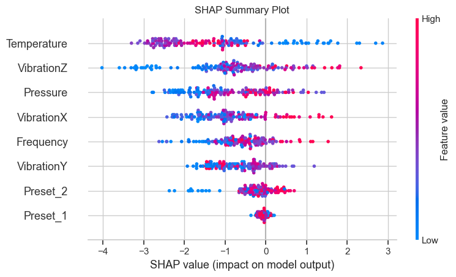

```python
explainer = shap.TreeExplainer(model)
shap_values = explainer.shap_values(X_test)

plt.title("SHAP Summary Plot")
shap.summary_plot(shap_values, X_test)
```

### Bonus: Production Architecture Flowchart

Below is a proposed Mermaid architecture for deploying this predictive model in a Databricks environment.

```
flowchart TD
    subgraph Data Layer [Data Collection & Storage - Delta Lake]
        Sensors[(IoT Sensors
on FPSO)] -->|Streaming/Batch
Kafka / Event Hubs| Ingestion[Structured Streaming Job
Databricks]
        Ingestion -->|Raw Data| Bronze[(Bronze Tables)]
        Bronze -->|Cleansing & Validations| Silver[(Silver Tables)]
        Silver -->|Feature Engineering| Gold[(Gold Tables /
Databricks Feature Store)]
    end

    subgraph Training Layer [Model Training & Management]
        Gold --> Train[Model Training Pipeline]
        Train -->|Hyperopt & MLflow| MLflow[MLflow Model Registry]
    end

    subgraph Serving Layer [Deployment & Serving]
        MLflow -->|Approve to Production| InferenceJob
        Gold --> InferenceJob[Batch/Streaming Inference Job]
        InferenceJob -->|Write Predictions| PredTable[(Predictions Table)]
        InferenceJob --> |Real-time API| ModelServing[Databricks Model Serving]
    end

    subgraph Action & Monitoring
        PredTable --> Dashboard[PowerBI / Databricks SQL Dashboard]
        ModelServing --> Alerts[Maintenance Alerts]
    end
```

**Architecture Discussion:**

- **Training Process:** The model runs incrementally when significant new failure data is ingested, tracked by **MLflow**.
- **Inference Time:** Depending on use cases, streaming structured jobs (millisecond latency) or Model Serving endpoints evaluate real-time batches of sensor readings.
- **Optimization:** We utilize the **Databricks Feature Store** to maintain a single source of truth for lagged features and aggregates. Model optimization can involve `hyperopt` for parameter selection.